# LATIHAN SOAL PERTEMUAN 4

Berliana Destari Hermansyah

2025-09-22

### 1. Proses MA(2)

### White Noise

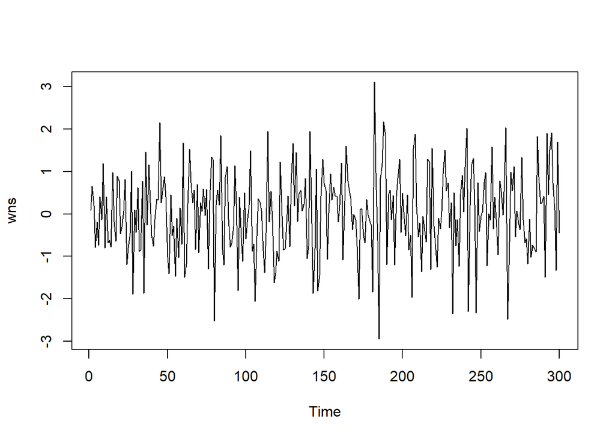

```r
set.seed(1055)
wns <- rnorm(300)
ts.plot(wns)
```

White noise dibangkitkan dengan rnorm(300) menghasilkan deret acak tanpa pola tren atau musiman. Plot time series hanya menunjukkan fluktuasi acak di sekitar nol.

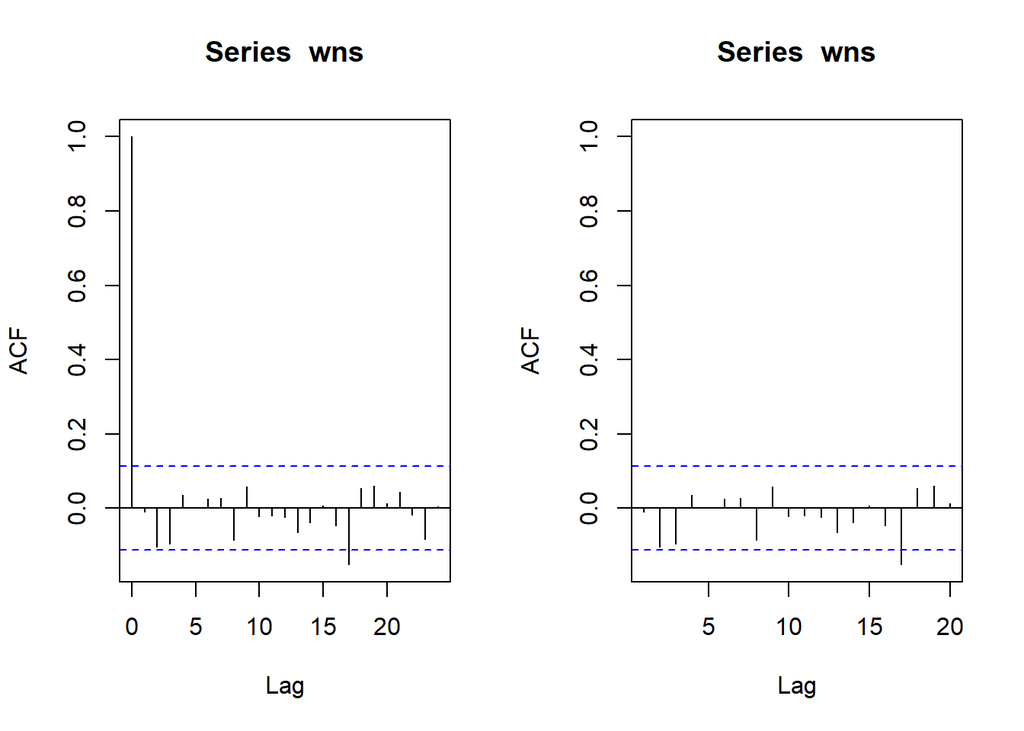

```r
par(mfrow = c(1, 2))
acf(wns)
acf(wns, xlim = c(1, 20))
```

### Proses MA

Proses MA secara umum
$$y_{t} = c + e_t + \theta_{1}e_{t-1} + \theta_{2}e_{t-2} + \dots +
\theta_{q}e_{t-q} = c+{e_t+\sum_{i=1}^p \theta_ie_{t-i}}$$
### Pembangkitan Proses untuk MA (2) Akan dilakukan pembangkitan pada proses MA (2) dengan $\theta 1 = 0.4$ dan $\theta 2 = 0.6$ sebanyak 300 observasi dan $c=0$. Karena diperlukan satu nilai awal untuk $e_{t-1}$ serta $e_{t-2}$ maka akan dimasukkan dua nilai pertama white noise sebagai nilai awal.

```r
set.seed(1055)
ma2 <- wns[1:2]
```

```r
for (i in 3:300) {
  ma2[i] <- wns[i] + 0.4 * wns[i - 1] + 0.6 * wns[i - 2]
}
ma2
```

```
##   [1]  0.089721904  0.657169965  0.514950035 -0.319086773 -0.381376620
##   [6] -1.289627495 -0.003543104 -0.417748531  1.381008149 -0.408815871
##  [11]  0.793312591 -1.010304646 -0.659348243 -1.445569729  0.287514941
##  [16] -0.271785588 -0.129035881  0.518857309  0.759460986  0.381380609
##  [21] -0.019398413 -0.327557815  0.665310681 -0.813620585 -0.780863930
##  [26] -1.483280239  0.350399302 -1.755478209 -0.057527647 -1.534326269
##  [31]  0.495391450 -0.890217164 -0.824028263 -0.095792827 -2.065465108
##  [36]  1.173293357 -0.797305373  1.927095514  0.566894651  0.284782617
##  [41] -0.810160122 -0.746814043 -0.163500460  0.386484112  2.487830901
##  [46]  1.321981771  1.934659049  1.256713849  1.084440328 -0.327049802
##  [51] -1.565857502 -0.725416036 -1.174560758 -0.217501964 -1.893112326
##  [56] -0.864168682 -1.954793010 -0.328496334 -1.274296140  1.473711361
##  [61] -1.258179140 -0.778481473 -1.130498383  0.913128835  1.499479819
##  [66]  1.482879259  1.120275348 -0.445875783  0.696668460 -1.134487208
##  [71]  0.312655727 -0.384861920  0.768767914  0.236361766  0.915640933
```

[output cut: 45 more lines]

### Fungsi arima.sim()

```r
ma_2 <- arima.sim(list(order=c(0,0,2), ma=c(0.4, 0.6)), n=300)
ma_2
```

```
## Time Series:
## Start = 1
## End = 300
## Frequency = 1
##   [1]  0.514950035 -0.319086773 -0.381376620 -1.289627495 -0.003543104
##   [6] -0.417748531  1.381008149 -0.408815871  0.793312591 -1.010304646
##  [11] -0.659348243 -1.445569729  0.287514941 -0.271785588 -0.129035881
##  [16]  0.518857309  0.759460986  0.381380609 -0.019398413 -0.327557815
##  [21]  0.665310681 -0.813620585 -0.780863930 -1.483280239  0.350399302
##  [26] -1.755478209 -0.057527647 -1.534326269  0.495391450 -0.890217164
##  [31] -0.824028263 -0.095792827 -2.065465108  1.173293357 -0.797305373
##  [36]  1.927095514  0.566894651  0.284782617 -0.810160122 -0.746814043
##  [41] -0.163500460  0.386484112  2.487830901  1.321981771  1.934659049
##  [46]  1.256713849  1.084440328 -0.327049802 -1.565857502 -0.725416036
##  [51] -1.174560758 -0.217501964 -1.893112326 -0.864168682 -1.954793010
```

[output cut: 49 more lines]

### Karakteristik MA (2)

### Plot Time Series

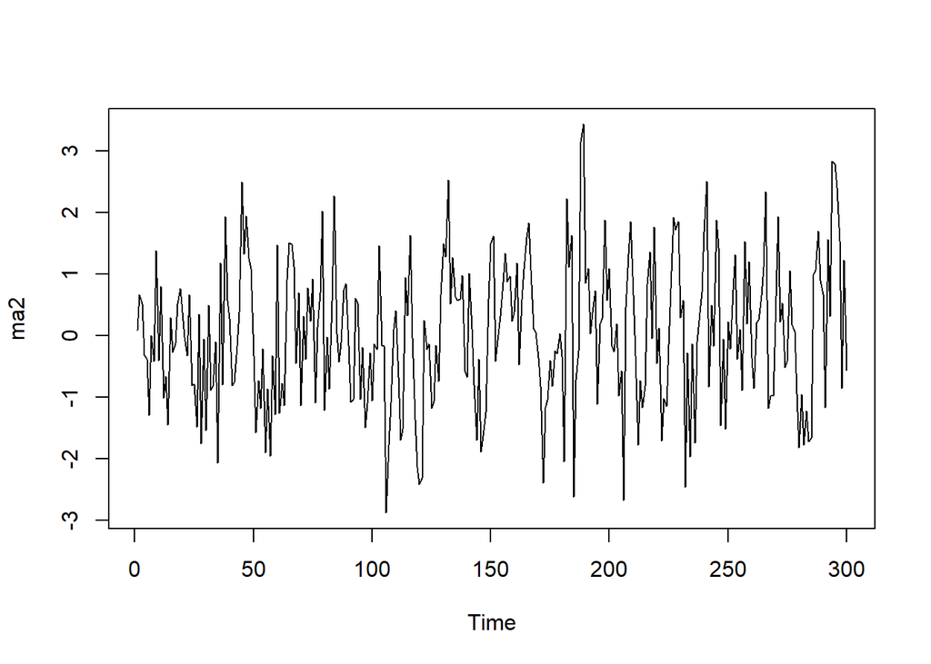

```r
ts.plot(ma2)
```

Deret hasil simulasi MA(2) pada grafik tersebut *menunjukkan sifat stasioner* baik dalam rataan maupun dalam ragam. Nilai-nilainya berfluktuasi di sekitar nol tanpa adanya kecenderungan naik atau turun, sehingga rataannya konstan dari waktu ke waktu. Besarnya penyebaran atau variasi data juga tampak relatif sama sepanjang rentang observasi, sehingga ragamnya konstan.

### Plot ACF

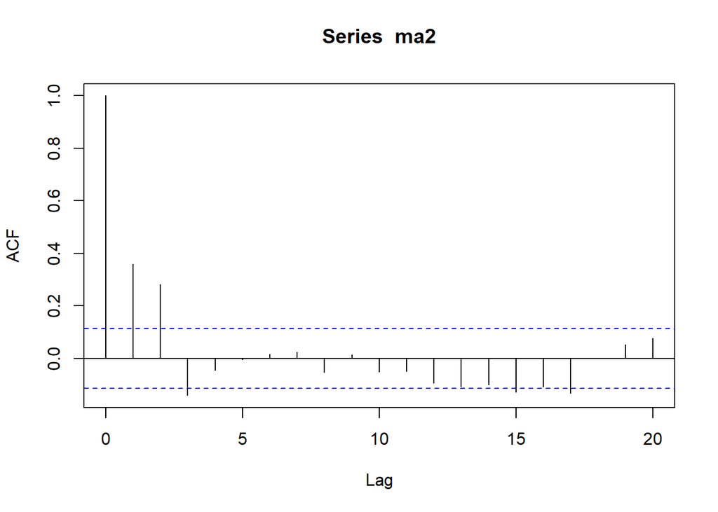

```r
acf(ma2,lag.max = 20)
```

### Plot PACF

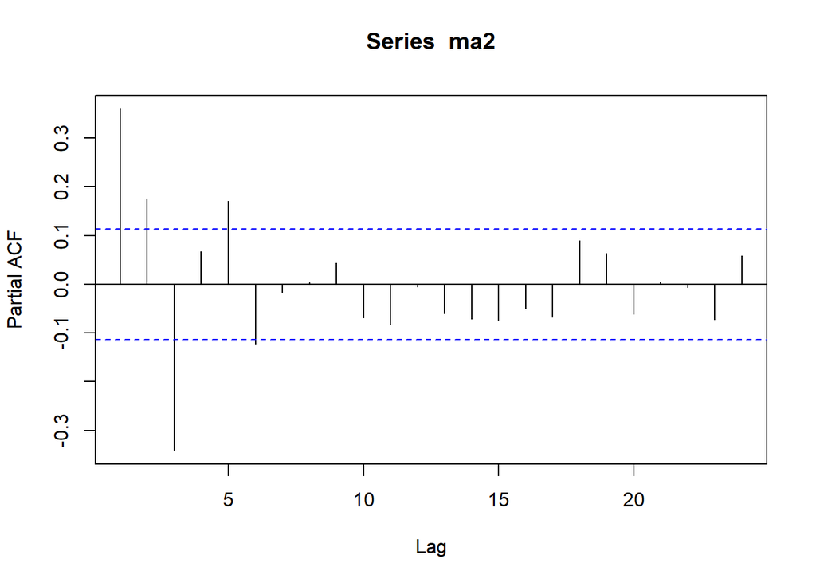

```r
pacf(ma2)
```

Berdasarkan plot PACF tersebut, terlihat bahwa pola PACF tidak berhenti tiba-tiba, melainkan *cenderung tails off.* Pola ini menunjukkan bahwa nilai PACF berfluktuasi naik-turun dengan kecenderungan membentuk *gelombang sinus yang teredam,* di mana amplitudo makin mengecil seiring bertambahnya lag dan akhirnya mendekati nol.

### Plot EACF

```r
TSA::eacf(ma2)
```

```
## AR/MA
##   0 1 2 3 4 5 6 7 8 9 10 11 12 13
## 0 x x x o o o o o o o o  o  o  o
## 1 x x x o o o o o o o o  o  o  o
## 2 x x x x o o o o o o o  o  o  o
## 3 x x o x o o o o o o o  o  o  o
## 4 x x o o o o o o o o o  o  o  o
## 5 x x x o o o o o o o o  o  o  o
## 6 o o x x o x o o o o o  o  o  o
## 7 o o o o o o o o o o o  o  o  o
```

Berdasarkan pola segitiga nol pada plot EACF, terlihat bahwa segitiga nol berada pada ordo AR(0) dan ordo MA(3).

### Scatterplot Antar Lag

#### Korelasi antara $Y_t$ dengan $Y_{t-1}$

```r
#Yt
yt_ma <- ma2[-1]
yt_ma
```

```
##   [1]  0.657169965  0.514950035 -0.319086773 -0.381376620 -1.289627495
##   [6] -0.003543104 -0.417748531  1.381008149 -0.408815871  0.793312591
##  [11] -1.010304646 -0.659348243 -1.445569729  0.287514941 -0.271785588
##  [16] -0.129035881  0.518857309  0.759460986  0.381380609 -0.019398413
##  [21] -0.327557815  0.665310681 -0.813620585 -0.780863930 -1.483280239
##  [26]  0.350399302 -1.755478209 -0.057527647 -1.534326269  0.495391450
##  [31] -0.890217164 -0.824028263 -0.095792827 -2.065465108  1.173293357
##  [36] -0.797305373  1.927095514  0.566894651  0.284782617 -0.810160122
##  [41] -0.746814043 -0.163500460  0.386484112  2.487830901  1.321981771
##  [46]  1.934659049  1.256713849  1.084440328 -0.327049802 -1.565857502
##  [51] -0.725416036 -1.174560758 -0.217501964 -1.893112326 -0.864168682
##  [56] -1.954793010 -0.328496334 -1.274296140  1.473711361 -1.258179140
##  [61] -0.778481473 -1.130498383  0.913128835  1.499479819  1.482879259
##  [66]  1.120275348 -0.445875783  0.696668460 -1.134487208  0.312655727
##  [71] -0.384861920  0.768767914  0.236361766  0.915640933 -1.088926616
```

[output cut: 45 more lines]

```r
#Yt-1
yt_1_ma <- ma2[-300]
yt_1_ma
```

```
##   [1]  0.089721904  0.657169965  0.514950035 -0.319086773 -0.381376620
##   [6] -1.289627495 -0.003543104 -0.417748531  1.381008149 -0.408815871
##  [11]  0.793312591 -1.010304646 -0.659348243 -1.445569729  0.287514941
##  [16] -0.271785588 -0.129035881  0.518857309  0.759460986  0.381380609
##  [21] -0.019398413 -0.327557815  0.665310681 -0.813620585 -0.780863930
##  [26] -1.483280239  0.350399302 -1.755478209 -0.057527647 -1.534326269
##  [31]  0.495391450 -0.890217164 -0.824028263 -0.095792827 -2.065465108
##  [36]  1.173293357 -0.797305373  1.927095514  0.566894651  0.284782617
##  [41] -0.810160122 -0.746814043 -0.163500460  0.386484112  2.487830901
##  [46]  1.321981771  1.934659049  1.256713849  1.084440328 -0.327049802
##  [51] -1.565857502 -0.725416036 -1.174560758 -0.217501964 -1.893112326
##  [56] -0.864168682 -1.954793010 -0.328496334 -1.274296140  1.473711361
##  [61] -1.258179140 -0.778481473 -1.130498383  0.913128835  1.499479819
##  [66]  1.482879259  1.120275348 -0.445875783  0.696668460 -1.134487208
##  [71]  0.312655727 -0.384861920  0.768767914  0.236361766  0.915640933
```

[output cut: 45 more lines]

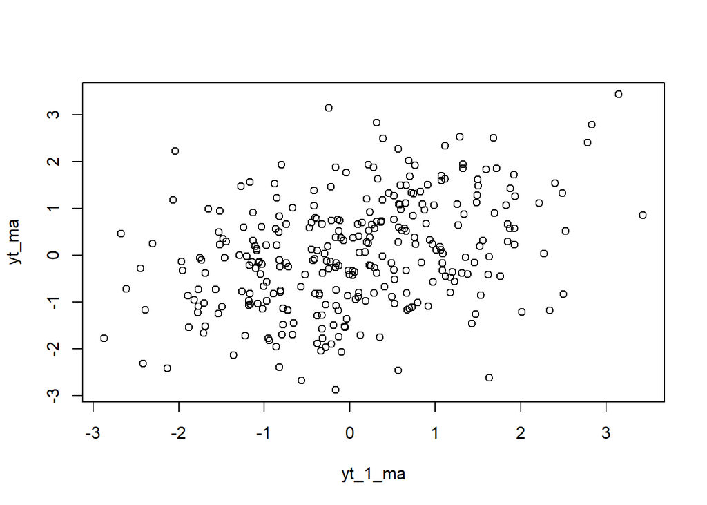

```r
plot(y=yt_ma,x=yt_1_ma)
```

```r
cor(yt_ma,yt_1_ma)
```

```
## [1] 0.359844
```

Nilai korelasi 0.359844 menunjukkan ada hubungan positif yang cukup lemah sampai sedang antara $y_t$ma dengan$y_t-1$ma Artinya, ketika nilai lag sebelumnya meningkat, nilai saat ini cenderung ikut naik meskipun tidak selalu konsisten. Scatter plot yang terlihat acak tadi memang tidak menunjukkan pola linier yang kuat, tetapi dengan korelasi sekitar 0.36, masih ada kecenderungan titik-titik membentuk arah diagonal positif yang samar. Jadi, meskipun visualnya tampak menyebar, ada indikasi ketergantungan moderat antar lag.

#### Korelasi antara $Y_t$ dengan $Y_{t-2}$

```r
#Yt
yt_ma2 <- ma2[-c(1,2)]
yt_ma2
```

```
##   [1]  0.514950035 -0.319086773 -0.381376620 -1.289627495 -0.003543104
##   [6] -0.417748531  1.381008149 -0.408815871  0.793312591 -1.010304646
##  [11] -0.659348243 -1.445569729  0.287514941 -0.271785588 -0.129035881
##  [16]  0.518857309  0.759460986  0.381380609 -0.019398413 -0.327557815
##  [21]  0.665310681 -0.813620585 -0.780863930 -1.483280239  0.350399302
##  [26] -1.755478209 -0.057527647 -1.534326269  0.495391450 -0.890217164
##  [31] -0.824028263 -0.095792827 -2.065465108  1.173293357 -0.797305373
##  [36]  1.927095514  0.566894651  0.284782617 -0.810160122 -0.746814043
##  [41] -0.163500460  0.386484112  2.487830901  1.321981771  1.934659049
##  [46]  1.256713849  1.084440328 -0.327049802 -1.565857502 -0.725416036
##  [51] -1.174560758 -0.217501964 -1.893112326 -0.864168682 -1.954793010
##  [56] -0.328496334 -1.274296140  1.473711361 -1.258179140 -0.778481473
##  [61] -1.130498383  0.913128835  1.499479819  1.482879259  1.120275348
##  [66] -0.445875783  0.696668460 -1.134487208  0.312655727 -0.384861920
##  [71]  0.768767914  0.236361766  0.915640933 -1.088926616  0.139121816
```

[output cut: 45 more lines]

```r
#Yt-2
yt_2_ma <- ma2[-c(299,300)]
yt_2_ma
```

```
##   [1]  0.089721904  0.657169965  0.514950035 -0.319086773 -0.381376620
##   [6] -1.289627495 -0.003543104 -0.417748531  1.381008149 -0.408815871
##  [11]  0.793312591 -1.010304646 -0.659348243 -1.445569729  0.287514941
##  [16] -0.271785588 -0.129035881  0.518857309  0.759460986  0.381380609
##  [21] -0.019398413 -0.327557815  0.665310681 -0.813620585 -0.780863930
##  [26] -1.483280239  0.350399302 -1.755478209 -0.057527647 -1.534326269
##  [31]  0.495391450 -0.890217164 -0.824028263 -0.095792827 -2.065465108
##  [36]  1.173293357 -0.797305373  1.927095514  0.566894651  0.284782617
##  [41] -0.810160122 -0.746814043 -0.163500460  0.386484112  2.487830901
##  [46]  1.321981771  1.934659049  1.256713849  1.084440328 -0.327049802
##  [51] -1.565857502 -0.725416036 -1.174560758 -0.217501964 -1.893112326
##  [56] -0.864168682 -1.954793010 -0.328496334 -1.274296140  1.473711361
##  [61] -1.258179140 -0.778481473 -1.130498383  0.913128835  1.499479819
##  [66]  1.482879259  1.120275348 -0.445875783  0.696668460 -1.134487208
##  [71]  0.312655727 -0.384861920  0.768767914  0.236361766  0.915640933
```

[output cut: 45 more lines]

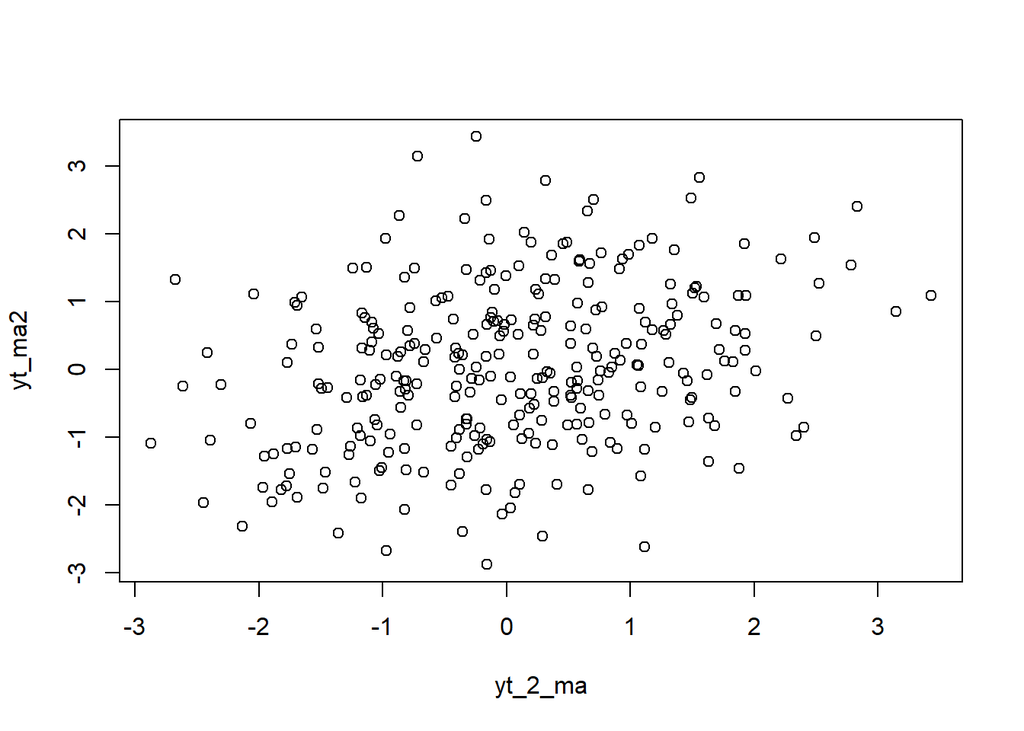

```r
plot(y=yt_ma2,x=yt_2_ma)
```

```r
cor(y=yt_ma2,x=yt_2_ma)
```

```
## [1] 0.2828222
```

Berdasarkan scatter plot antara $y_t$ma2 dengan $y_t-2$ma2, titik-titik terlihat cukup menyebar tanpa pola linier yang jelas. Nilai korelasi sebesar 0.2828222 menunjukkan adanya hubungan positif, tetapi lemah. Artinya, meskipun ada kecenderungan bahwa peningkatan nilai pada lag ke-2 diikuti oleh kenaikan nilai pada periode sekarang, hubungan tersebut tidak terlalu kuat. Ketergantungan antar lag ke-2 ada, tetapi lebih lemah dibandingkan dengan korelasi pada lag pertama yang sebelumnya lebih tinggi.

#### Korelasi antara $Y_t$ dengan $Y_{t-3}$

```r
#Yt
yt_ma3 <- ma2[-c(1,2,3)]
yt_ma3
```

```
##   [1] -0.319086773 -0.381376620 -1.289627495 -0.003543104 -0.417748531
##   [6]  1.381008149 -0.408815871  0.793312591 -1.010304646 -0.659348243
##  [11] -1.445569729  0.287514941 -0.271785588 -0.129035881  0.518857309
##  [16]  0.759460986  0.381380609 -0.019398413 -0.327557815  0.665310681
##  [21] -0.813620585 -0.780863930 -1.483280239  0.350399302 -1.755478209
##  [26] -0.057527647 -1.534326269  0.495391450 -0.890217164 -0.824028263
##  [31] -0.095792827 -2.065465108  1.173293357 -0.797305373  1.927095514
##  [36]  0.566894651  0.284782617 -0.810160122 -0.746814043 -0.163500460
##  [41]  0.386484112  2.487830901  1.321981771  1.934659049  1.256713849
##  [46]  1.084440328 -0.327049802 -1.565857502 -0.725416036 -1.174560758
##  [51] -0.217501964 -1.893112326 -0.864168682 -1.954793010 -0.328496334
##  [56] -1.274296140  1.473711361 -1.258179140 -0.778481473 -1.130498383
##  [61]  0.913128835  1.499479819  1.482879259  1.120275348 -0.445875783
##  [66]  0.696668460 -1.134487208  0.312655727 -0.384861920  0.768767914
##  [71]  0.236361766  0.915640933 -1.088926616  0.139121816  0.692444551
```

[output cut: 45 more lines]

```r
#Yt-2
yt_3_ma <- ma2[-c(298,299,300)]
yt_3_ma
```

```
##   [1]  0.089721904  0.657169965  0.514950035 -0.319086773 -0.381376620
##   [6] -1.289627495 -0.003543104 -0.417748531  1.381008149 -0.408815871
##  [11]  0.793312591 -1.010304646 -0.659348243 -1.445569729  0.287514941
##  [16] -0.271785588 -0.129035881  0.518857309  0.759460986  0.381380609
##  [21] -0.019398413 -0.327557815  0.665310681 -0.813620585 -0.780863930
##  [26] -1.483280239  0.350399302 -1.755478209 -0.057527647 -1.534326269
##  [31]  0.495391450 -0.890217164 -0.824028263 -0.095792827 -2.065465108
##  [36]  1.173293357 -0.797305373  1.927095514  0.566894651  0.284782617
##  [41] -0.810160122 -0.746814043 -0.163500460  0.386484112  2.487830901
##  [46]  1.321981771  1.934659049  1.256713849  1.084440328 -0.327049802
##  [51] -1.565857502 -0.725416036 -1.174560758 -0.217501964 -1.893112326
##  [56] -0.864168682 -1.954793010 -0.328496334 -1.274296140  1.473711361
##  [61] -1.258179140 -0.778481473 -1.130498383  0.913128835  1.499479819
##  [66]  1.482879259  1.120275348 -0.445875783  0.696668460 -1.134487208
##  [71]  0.312655727 -0.384861920  0.768767914  0.236361766  0.915640933
```

[output cut: 45 more lines]

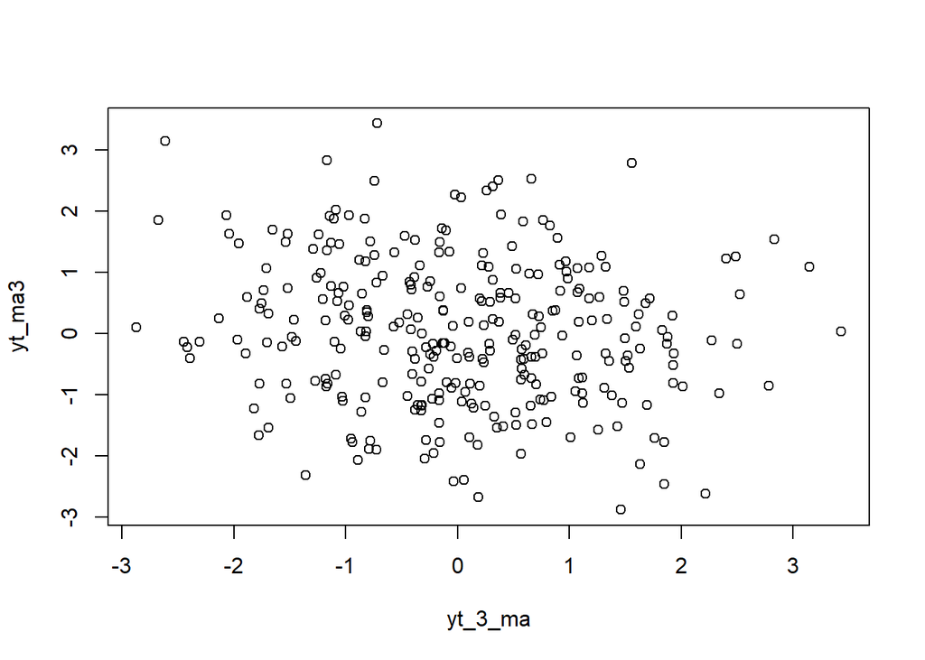

```r
plot(y=yt_ma3,x=yt_3_ma)
```

```r
cor(yt_ma3,yt_3_ma)
```

```
## [1] -0.1413105
```

### Perhitungan Korelasi Teoritis

$\rho_1 = \frac{0.4 + (0.4)(0.6)}{1 + 0.4^2 + 0.6^2} = 0.4211$

$\rho_2 = \frac{0.6}{1 + 0.4^2 + 0.6^2} = 0.3947$

$\rho_3 = 0$

```r
# Parameter MA(2)
theta1 <- 0.4
theta2 <- 0.6

# Varians (gamma0)
gamma0 <- 1 + theta1^2 + theta2^2

# Gamma1 dan Gamma2
gamma1 <- theta1 + theta1*theta2
gamma2 <- theta2

# Autokorelasi teoritis
rho1 <- gamma1 / gamma0
rho2 <- gamma2 / gamma0
rho3 <- 0 # karena k>q dimana q=2 dan k=3

rho1
```

```
## [1] 0.4210526
```

```r
rho2
```

```
## [1] 0.3947368
```

```r
rho3
```

```
## [1] 0
```

Korelasi antara $Y_t$ dengan $Y_t-1$ dan korelasi antara $Y_t$ dengan $Y_t-2$ dari hasil simulasi terlihat cukup mendekati nilai perhitungan teoritis, yaitu sekitar 0.42 untuk lag pertama dan 0.39 untuk lag kedua. Sementara itu, untuk korelasi $Y_t$ dengan $Y_t-3$ secara teori nilainya sama dengan nol karena proses yang digunakan adalah MA(2), sehingga ketergantungan hanya muncul sampai lag ke-2 saja.

### 2. Proses AR

Proses AR dapat dituliskan sebagai berikut:

$$y_{t} = c + e_t + \phi_{1}Y_{t-1} +
\phi_{2}Y_{t-2} + \dots + \phi_{q}Y_{t-q} = c+{e_t+\sum_{i=1}^p
\phi_iY_{t-i}}$$
Terlihat bahwa $Y_t$ berperan penting dalam pembangkitan proses AR.

### Pembangkitan Proses untuk AR (2)

Akan dilakukan pembangkitan untuk proses AR (2) dengan $\phi = 0.5$ dan $\phi = 0.2$ sebanyak 300 observasi dan $c=0$.

$$Y_t = e_t+0.5Y_{t-1}+0.2Y_{t-2}$$

```r
set.seed(1055)
```

```r
n <- length(wns)
n
```

```
## [1] 300
```

```r
ar2 <- c(1:n)
for (i in 3:n) {
  ar2[i] <- wns[i] + 0.5 * ar2[i - 1] + 0.2 * ar2[i - 2]
}
ar2
```

```
##   [1]  1.00000000  2.00000000  1.39824891  0.30643614  0.24961721 -0.55461842
##   [7]  0.17530721 -0.15766725  1.14937905 -0.26228199  0.49833189 -0.49017109
##  [13] -0.76977340 -1.26662057  0.18834238 -0.35096166 -0.77548915  0.43107636
##  [19]  0.84690211  0.04305427 -0.11372309  0.02601099  0.80864527 -0.77600651
##  [25] -1.02395623 -1.12006804  0.24533870 -1.98915488 -0.85401148 -1.26307590
##  [31] -0.18655206 -1.21948014 -1.49111608 -0.22346730 -2.27537732  0.27748736
##  [37] -0.57833268  0.92230532  0.60719164 -0.02542722 -0.65306507 -0.46562565
##  [43] -0.01624936  0.22676831  2.25845205  1.44042348  1.71123302  2.02517643
##  [49]  1.76308653  0.26734293 -0.91682551  0.04242688 -0.67379227 -0.60967911
##  [55] -1.91321863 -1.18450456 -2.00313287 -1.09209328 -1.66257686  0.62254129
##  [61] -1.51878103 -1.81769824 -0.97145553  0.67709109  0.88850098  0.84903425
##  [67]  1.16819853 -0.07998148  0.88428374 -0.48426299  0.19716354  0.05813708
##  [73]  0.65724303  0.30726924  0.86067097 -0.80758457  0.08186064  1.22607480
##  [79]  1.91727132 -1.32686284 -0.06684397  0.26659112  0.33145269  2.06432552
##  [85]  0.26630309 -0.66015829  0.58847977  1.28029061  0.63168988 -0.20627037
```

[output cut: 35 more lines]

###Pembangkitan dengan arima.sim()

```r
ar_2 <- arima.sim(list(order=c(2,0,0), ar=c(0.5, 0.2)), n=300)
ar_2
```

```
## Time Series:
## Start = 1
## End = 300
## Frequency = 1
##   [1] -1.12176566  0.24404452 -1.99014150 -0.85476362 -1.26364929 -0.18698918
##   [7] -1.21981338 -1.49137013 -0.22366097 -2.27552496  0.27737480 -0.57841848
##  [13]  0.92223990  0.60714177 -0.02546524 -0.65309405 -0.46564774 -0.01626620
##  [19]  0.22675547  2.25844226  1.44041602  1.71122733  2.02517209  1.76308323
##  [25]  0.26734041 -0.91682743  0.04242542 -0.67379339 -0.60967996 -1.91321928
##  [31] -1.18450505 -2.00313325 -1.09209357 -1.66257708  0.62254112 -1.51878116
##  [37] -1.81769833 -0.97145561  0.67709104  0.88850094  0.84903422  1.16819850
##  [43] -0.07998149  0.88428372 -0.48426300  0.19716353  0.05813707  0.65724302
##  [49]  0.30726924  0.86067096 -0.80758457  0.08186064  1.22607480  1.91727132
##  [55] -1.32686284 -0.06684398  0.26659112  0.33145269  2.06432552  0.26630309
##  [61] -0.66015829  0.58847977  1.28029061  0.63168988 -0.20627037 -0.66617109
```

[output cut: 39 more lines]

### Karakteristik AR(2)

### Plot Time Series

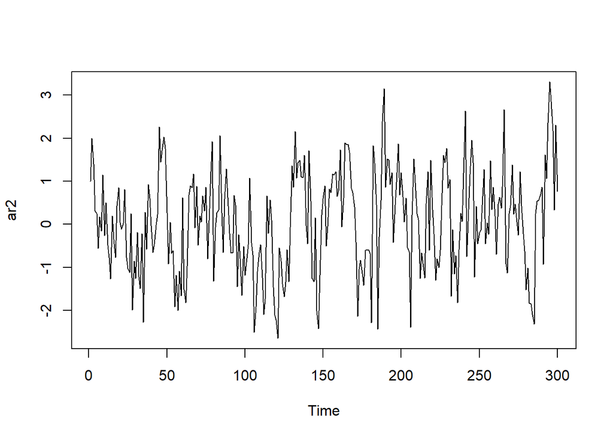

```r
ts.plot(ar2)
```

Berdasarkan plot deret waktu AR(2) tersebut, terlihat bahwa pola data berfluktuasi di sekitar nilai rata-rata nol tanpa adanya kecenderungan meningkat ataupun menurun secara konsisten, sehingga dapat dikatakan sudah stasioner dalam rataan. Selain itu, penyebaran atau amplitudo fluktuasi dari awal hingga akhir deret terlihat relatif stabil, tidak menunjukkan adanya pelebaran maupun penyempitan varians yang signifikan. Dengan demikian, deret waktu AR(2) ini dapat dikatakan *stasioner baik dalam rataan maupun varians.*

### Plot ACF

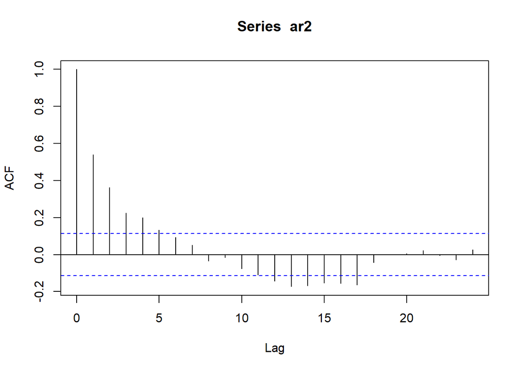

```r
acf(ar2)
```

### Plot PACF

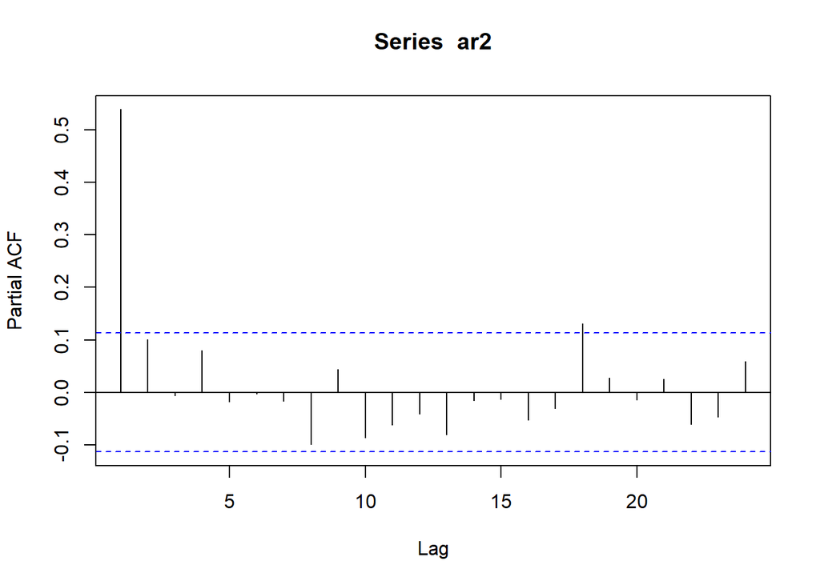

```r
pacf(ar2)
```

### Plot EACF

```r
TSA::eacf(ar2)
```

```
## AR/MA
##   0 1 2 3 4 5 6 7 8 9 10 11 12 13
## 0 x x x x x o o o o o o  x  x  x
## 1 x o x o o o o o o o o  o  o  o
## 2 o o o o o o o o o o o  o  o  o
## 3 o x x o o o o o o o o  o  o  o
## 4 x o x o o o o o o o o  o  o  o
## 5 o o o x o o o o o o o  o  o  o
## 6 o o o x o o o o o o o  o  o  o
## 7 x o x x x x o o o o o  o  o  o
```

### Korelasi antara $Y_t$ dengan $Y_t-1$

```r
#Yt
yt_ar <- ar2[-1]
yt_ar
```

```
##   [1]  2.00000000  1.39824891  0.30643614  0.24961721 -0.55461842  0.17530721
##   [7] -0.15766725  1.14937905 -0.26228199  0.49833189 -0.49017109 -0.76977340
##  [13] -1.26662057  0.18834238 -0.35096166 -0.77548915  0.43107636  0.84690211
##  [19]  0.04305427 -0.11372309  0.02601099  0.80864527 -0.77600651 -1.02395623
##  [25] -1.12006804  0.24533870 -1.98915488 -0.85401148 -1.26307590 -0.18655206
##  [31] -1.21948014 -1.49111608 -0.22346730 -2.27537732  0.27748736 -0.57833268
##  [37]  0.92230532  0.60719164 -0.02542722 -0.65306507 -0.46562565 -0.01624936
##  [43]  0.22676831  2.25845205  1.44042348  1.71123302  2.02517643  1.76308653
##  [49]  0.26734293 -0.91682551  0.04242688 -0.67379227 -0.60967911 -1.91321863
##  [55] -1.18450456 -2.00313287 -1.09209328 -1.66257686  0.62254129 -1.51878103
##  [61] -1.81769824 -0.97145553  0.67709109  0.88850098  0.84903425  1.16819853
##  [67] -0.07998148  0.88428374 -0.48426299  0.19716354  0.05813708  0.65724303
##  [73]  0.30726924  0.86067097 -0.80758457  0.08186064  1.22607480  1.91727132
##  [79] -1.32686284 -0.06684397  0.26659112  0.33145269  2.06432552  0.26630309
##  [85] -0.66015829  0.58847977  1.28029061  0.63168988 -0.20627037 -0.66617109
```

[output cut: 35 more lines]

```r
#Yt-1
yt_1_ar <- ar2[-300]
yt_1_ar
```

```
##   [1]  1.00000000  2.00000000  1.39824891  0.30643614  0.24961721 -0.55461842
##   [7]  0.17530721 -0.15766725  1.14937905 -0.26228199  0.49833189 -0.49017109
##  [13] -0.76977340 -1.26662057  0.18834238 -0.35096166 -0.77548915  0.43107636
##  [19]  0.84690211  0.04305427 -0.11372309  0.02601099  0.80864527 -0.77600651
##  [25] -1.02395623 -1.12006804  0.24533870 -1.98915488 -0.85401148 -1.26307590
##  [31] -0.18655206 -1.21948014 -1.49111608 -0.22346730 -2.27537732  0.27748736
##  [37] -0.57833268  0.92230532  0.60719164 -0.02542722 -0.65306507 -0.46562565
##  [43] -0.01624936  0.22676831  2.25845205  1.44042348  1.71123302  2.02517643
##  [49]  1.76308653  0.26734293 -0.91682551  0.04242688 -0.67379227 -0.60967911
##  [55] -1.91321863 -1.18450456 -2.00313287 -1.09209328 -1.66257686  0.62254129
##  [61] -1.51878103 -1.81769824 -0.97145553  0.67709109  0.88850098  0.84903425
##  [67]  1.16819853 -0.07998148  0.88428374 -0.48426299  0.19716354  0.05813708
##  [73]  0.65724303  0.30726924  0.86067097 -0.80758457  0.08186064  1.22607480
##  [79]  1.91727132 -1.32686284 -0.06684397  0.26659112  0.33145269  2.06432552
##  [85]  0.26630309 -0.66015829  0.58847977  1.28029061  0.63168988 -0.20627037
```

[output cut: 35 more lines]

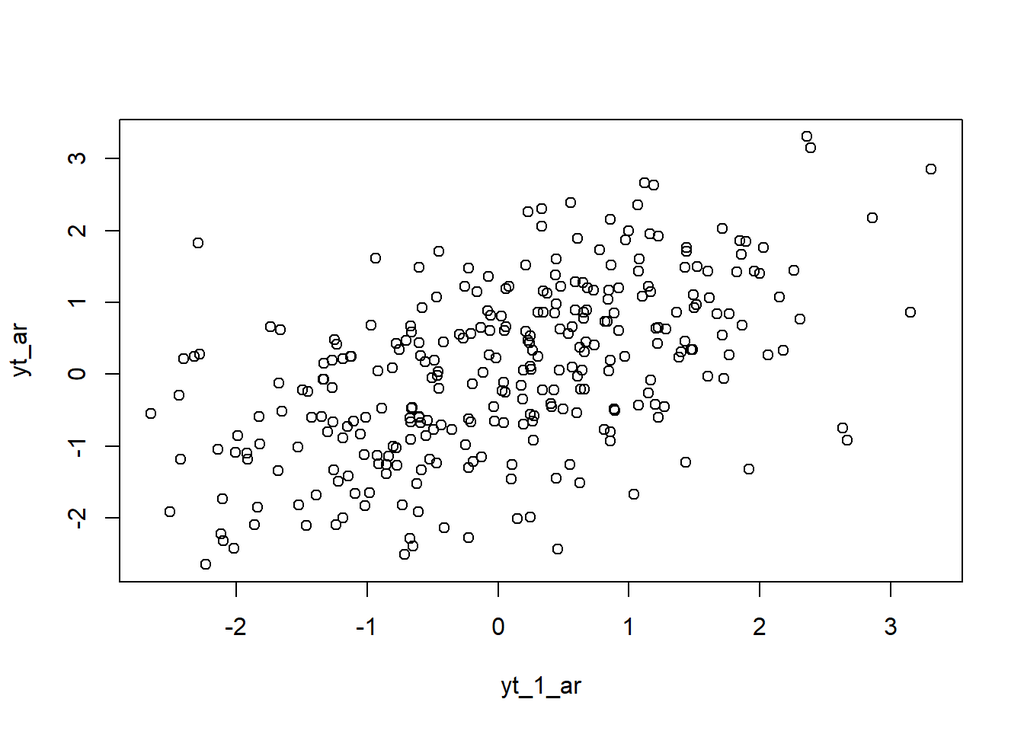

```r
plot(y=yt_ar,x=yt_1_ar)
```

```r
cor(yt_ar,yt_1_ar)
```

```
## [1] 0.5398381
```

Scatterplot antara $Y_t$ dengan $Y_t-1$ pada proses AR. Terlihat bahwa titik-titik cenderung menyebar mengikuti pola linier positif, artinya ketika nilai $Y_t-1$ tinggi maka $Y_t$ juga cenderung tinggi, dan sebaliknya. Hal ini mengindikasikan adanya hubungan yang cukup kuat antara nilai saat ini dengan nilai sebelumnya. Nilai korelasinya sebesar 0.5398, yang berarti korelasi positif dengan kekuatan sedang menuju kuat.

```r
#Yt
yt_ar2 <- ar2[-c(1,2)]
yt_ar2
```

```
##   [1]  1.39824891  0.30643614  0.24961721 -0.55461842  0.17530721 -0.15766725
##   [7]  1.14937905 -0.26228199  0.49833189 -0.49017109 -0.76977340 -1.26662057
##  [13]  0.18834238 -0.35096166 -0.77548915  0.43107636  0.84690211  0.04305427
##  [19] -0.11372309  0.02601099  0.80864527 -0.77600651 -1.02395623 -1.12006804
##  [25]  0.24533870 -1.98915488 -0.85401148 -1.26307590 -0.18655206 -1.21948014
##  [31] -1.49111608 -0.22346730 -2.27537732  0.27748736 -0.57833268  0.92230532
##  [37]  0.60719164 -0.02542722 -0.65306507 -0.46562565 -0.01624936  0.22676831
##  [43]  2.25845205  1.44042348  1.71123302  2.02517643  1.76308653  0.26734293
##  [49] -0.91682551  0.04242688 -0.67379227 -0.60967911 -1.91321863 -1.18450456
##  [55] -2.00313287 -1.09209328 -1.66257686  0.62254129 -1.51878103 -1.81769824
##  [61] -0.97145553  0.67709109  0.88850098  0.84903425  1.16819853 -0.07998148
##  [67]  0.88428374 -0.48426299  0.19716354  0.05813708  0.65724303  0.30726924
##  [73]  0.86067097 -0.80758457  0.08186064  1.22607480  1.91727132 -1.32686284
##  [79] -0.06684397  0.26659112  0.33145269  2.06432552  0.26630309 -0.66015829
##  [85]  0.58847977  1.28029061  0.63168988 -0.20627037 -0.66617109 -0.66670932
```

[output cut: 35 more lines]

```r
#Yt-2
yt_2_ar <- ar2[-c(299,300)]
yt_2_ar
```

```
##   [1]  1.00000000  2.00000000  1.39824891  0.30643614  0.24961721 -0.55461842
##   [7]  0.17530721 -0.15766725  1.14937905 -0.26228199  0.49833189 -0.49017109
##  [13] -0.76977340 -1.26662057  0.18834238 -0.35096166 -0.77548915  0.43107636
##  [19]  0.84690211  0.04305427 -0.11372309  0.02601099  0.80864527 -0.77600651
##  [25] -1.02395623 -1.12006804  0.24533870 -1.98915488 -0.85401148 -1.26307590
##  [31] -0.18655206 -1.21948014 -1.49111608 -0.22346730 -2.27537732  0.27748736
##  [37] -0.57833268  0.92230532  0.60719164 -0.02542722 -0.65306507 -0.46562565
##  [43] -0.01624936  0.22676831  2.25845205  1.44042348  1.71123302  2.02517643
##  [49]  1.76308653  0.26734293 -0.91682551  0.04242688 -0.67379227 -0.60967911
##  [55] -1.91321863 -1.18450456 -2.00313287 -1.09209328 -1.66257686  0.62254129
##  [61] -1.51878103 -1.81769824 -0.97145553  0.67709109  0.88850098  0.84903425
##  [67]  1.16819853 -0.07998148  0.88428374 -0.48426299  0.19716354  0.05813708
##  [73]  0.65724303  0.30726924  0.86067097 -0.80758457  0.08186064  1.22607480
##  [79]  1.91727132 -1.32686284 -0.06684397  0.26659112  0.33145269  2.06432552
##  [85]  0.26630309 -0.66015829  0.58847977  1.28029061  0.63168988 -0.20627037
```

[output cut: 35 more lines]

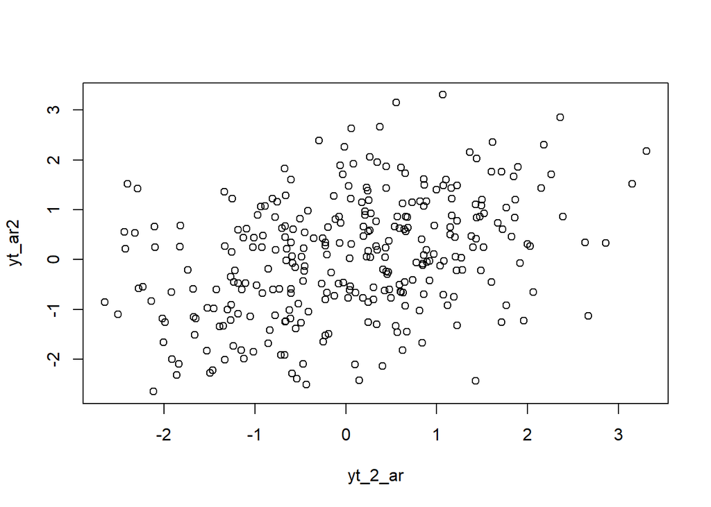

```r
plot(y=yt_ar2,x=yt_2_ar)
```

```r
cor(yt_ar2,yt_2_ar)
```

```
## [1] 0.3663777
```

Scatter plot antara $Y_t$ dengan $Y_t21$ Titik-titik terlihat lebih menyebar dibandingkan dengan plot $Y_t$ terhadap $Y_t-1$ meskipun masih ada kecenderungan pola positif. Artinya, nilai sekarang$Y_t$ masih dipengaruhi oleh nilai dua periode sebelumnya $Y_t-1=2$ tetapi kekuatannya lebih lemah. Nilai korelasinya sebesar 0.3664, yang menunjukkan korelasi positif sedang. Ini konsisten dengan karakteristik model AR(2), di mana pengaruh $Y_t-2$ masih ada tetapi tidak sekuat pengaruh $Y_t-1$

### Korelasi antara $Y_t$ dengan $Y_t-3$

```r
#Yt
yt_ar3 <- ar2[-c(1,2,3)]
yt_ar3
```

```
##   [1]  0.30643614  0.24961721 -0.55461842  0.17530721 -0.15766725  1.14937905
##   [7] -0.26228199  0.49833189 -0.49017109 -0.76977340 -1.26662057  0.18834238
##  [13] -0.35096166 -0.77548915  0.43107636  0.84690211  0.04305427 -0.11372309
##  [19]  0.02601099  0.80864527 -0.77600651 -1.02395623 -1.12006804  0.24533870
##  [25] -1.98915488 -0.85401148 -1.26307590 -0.18655206 -1.21948014 -1.49111608
##  [31] -0.22346730 -2.27537732  0.27748736 -0.57833268  0.92230532  0.60719164
##  [37] -0.02542722 -0.65306507 -0.46562565 -0.01624936  0.22676831  2.25845205
##  [43]  1.44042348  1.71123302  2.02517643  1.76308653  0.26734293 -0.91682551
##  [49]  0.04242688 -0.67379227 -0.60967911 -1.91321863 -1.18450456 -2.00313287
##  [55] -1.09209328 -1.66257686  0.62254129 -1.51878103 -1.81769824 -0.97145553
##  [61]  0.67709109  0.88850098  0.84903425  1.16819853 -0.07998148  0.88428374
##  [67] -0.48426299  0.19716354  0.05813708  0.65724303  0.30726924  0.86067097
##  [73] -0.80758457  0.08186064  1.22607480  1.91727132 -1.32686284 -0.06684397
##  [79]  0.26659112  0.33145269  2.06432552  0.26630309 -0.66015829  0.58847977
##  [85]  1.28029061  0.63168988 -0.20627037 -0.66617109 -0.66670932  0.67384666
```

[output cut: 35 more lines]

```r
#Yt-2
yt_3_ar <- ar2[-c(298,299,300)]
yt_3_ar
```

```
##   [1]  1.00000000  2.00000000  1.39824891  0.30643614  0.24961721 -0.55461842
##   [7]  0.17530721 -0.15766725  1.14937905 -0.26228199  0.49833189 -0.49017109
##  [13] -0.76977340 -1.26662057  0.18834238 -0.35096166 -0.77548915  0.43107636
##  [19]  0.84690211  0.04305427 -0.11372309  0.02601099  0.80864527 -0.77600651
##  [25] -1.02395623 -1.12006804  0.24533870 -1.98915488 -0.85401148 -1.26307590
##  [31] -0.18655206 -1.21948014 -1.49111608 -0.22346730 -2.27537732  0.27748736
##  [37] -0.57833268  0.92230532  0.60719164 -0.02542722 -0.65306507 -0.46562565
##  [43] -0.01624936  0.22676831  2.25845205  1.44042348  1.71123302  2.02517643
##  [49]  1.76308653  0.26734293 -0.91682551  0.04242688 -0.67379227 -0.60967911
##  [55] -1.91321863 -1.18450456 -2.00313287 -1.09209328 -1.66257686  0.62254129
##  [61] -1.51878103 -1.81769824 -0.97145553  0.67709109  0.88850098  0.84903425
##  [67]  1.16819853 -0.07998148  0.88428374 -0.48426299  0.19716354  0.05813708
##  [73]  0.65724303  0.30726924  0.86067097 -0.80758457  0.08186064  1.22607480
##  [79]  1.91727132 -1.32686284 -0.06684397  0.26659112  0.33145269  2.06432552
##  [85]  0.26630309 -0.66015829  0.58847977  1.28029061  0.63168988 -0.20627037
```

[output cut: 35 more lines]

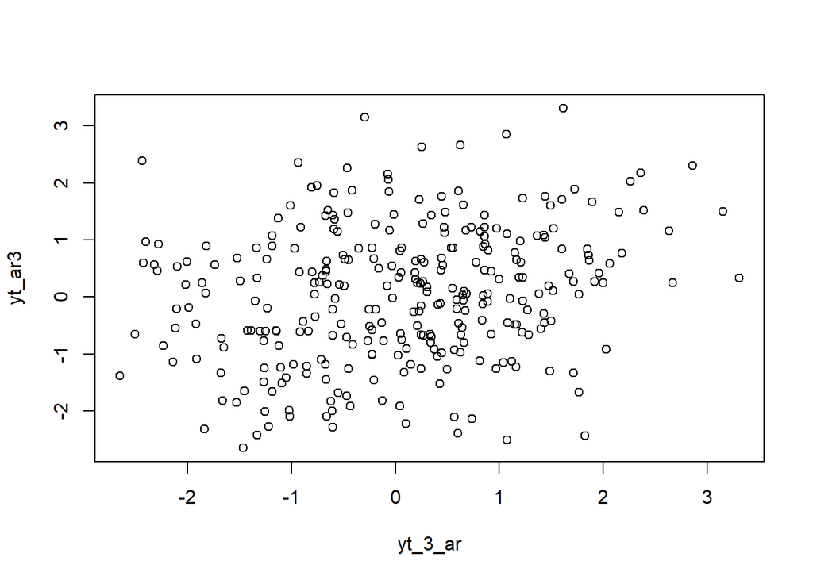

```r
plot(y=yt_ar3,x=yt_3_ar)
```

```r
cor(yt_ar3,yt_3_ar)
```

```
## [1] 0.2284304
```

Scatter plot antara $Y_t$ dengan $Y_t-3$, titik-titik terlihat cukup menyebar acak, dengan pola yang jauh lebih lemah dibandingkan pada lag 1 maupun lag 2. Hal ini menandakan bahwa pengaruh nilai tiga periode sebelumnya $Y_t-3$ terhadap nilai saat ini $Y_t$ semakin berkurang. Nilai korelasinya sebesar 0.2284, yang berarti korelasi positif tetapi relatif lemah.

### Perhitungan Korelasi Teoritis

$$\rho_1=\frac{\phi_1}{1-\phi_2}=\frac{0.5}{1-0.2}=\frac{0.5}{0.8}=0.625$$

$$\rho_2=\phi_1\rho_1+\phi_2=(0.5)(0.625)+0.2=0.3125+0.2=0.5125$$

$$\rho_3=\phi_1\rho_2+\phi_2\rho_1=(0.5)(0.5125)+(0.2)(0.625)=0.25625+0.125=0.38125$$

```r
# Parameter AR(2)
phi1 <- 0.5
phi2 <- 0.2
sigma2 <- 1   # varians white noise (tidak mempengaruhi rho)

# Autokorelasi teoritis sampai lag 3
rho1 <- phi1 / (1 - phi2)
rho2 <- phi1 * rho1 + phi2
rho3 <- phi1 * rho2 + phi2 * rho1

round(c(rho1 = rho1, rho2 = rho2, rho3 = rho3), 6)
```

```
##    rho1    rho2    rho3
## 0.62500 0.51250 0.38125
```

### ARMA (2,2)

### Fungsi Pembangkitan ARMA

Formula umum ARMA:
$$y_{t} = c + \sum_{i=1}^p \phi_{i}y_{t-i} + \sum_{j=1}^q e_{t-j}+ e_{t}$$

Akan dilakukan pembangkitan ARMA dengan $\theta1$=0.4 dan $\theta2$=0.6 dengan $\phi$=0.5 dan $\phi$=0.2 sebanyak 300 observasi dan $c$=0.

$Y_t = 0.5Y_{t-1} + 0.2Y_{t-2} + e_t + 0.4e_{t-1} + 0.6e_{t-2}$

```r
set.seed(1055)
n = length(wns)
theta1 = 0.4
theta2 = 0.6
phi1 = 0.5
phi2 = 0.2

y.arma2=c(1:n)
for (i in 3:n) {
  y.arma2[i] <- phi1*y.arma2[i-1] +
               phi2*y.arma2[i-2] +
               wns[i] +
               theta1*wns[i-1] +
               theta2*wns[i-2]
}
y.arma2
```

```
##   [1]  1.000000000  2.000000000  1.714950035  0.938388244  0.430807510
##   [6] -0.886546091 -0.360654647 -0.775385073  0.921184684 -0.103300544
##  [11]  0.925899255 -0.568015127 -0.758175956 -1.938260732 -0.833250616
##  [16] -1.076063042 -0.833717525 -0.113214062  0.536110450  0.626793022
##  [21]  0.401220188 -0.001589117  0.744760161 -0.441558328 -0.852691062
##  [26] -1.997937436 -0.819107628 -2.564619510 -1.503658927 -2.799079634
##  [31] -1.204880153 -2.052473167 -2.091240877 -1.551907899 -3.259667233
##  [36] -0.766921839 -1.832699739  0.857361276  0.629035342  0.770772543
##  [41] -0.298966782 -0.742142926 -0.594365279 -0.059127113  2.339394288
##  [46]  2.479853493  3.642464653  3.573916874  3.599891696  2.187679421
##  [51]  0.247960547 -0.163899878 -1.206918588 -0.853741234 -2.561366660
##  [56] -2.315600259 -3.624866471 -2.604049622 -3.301294245 -0.697745686
##  [61] -2.267310832 -2.051686027 -2.609803563 -0.802110151  0.576464031
##  [66]  1.610689244  2.040912776  0.896718454  1.553210242 -0.178538396
##  [71]  0.534028577 -0.153555310  0.798795974  0.605048691  1.377924473
```

[output cut: 45 more lines]

### Pembangkitan dengan arima.sim()

```r
arma22 <- arima.sim(list(order=c(2,0,2), ar=c(0.5, 0.2), ma=c(0.4, 0.6)), n=300)
arma22
```

```
## Time Series:
## Start = 1
## End = 300
## Frequency = 1
##   [1] -2.566071942 -1.504766185 -2.799923750 -1.205523662 -2.052963745
##   [6] -2.091614868 -1.552193010 -3.259884587 -0.767087538 -1.832826060
##  [11]  0.857264976  0.628961928  0.770716576 -0.299009449 -0.742175453
##  [16] -0.594390076 -0.059146016  2.339379877  2.479842507  3.642456278
##  [21]  3.573910489  3.599886828  2.187675710  0.247957718 -0.163902035
##  [26] -1.206920232 -0.853742487 -2.561367616 -2.315600987 -3.624867026
##  [31] -2.604050045 -3.301294568 -0.697745932 -2.267311020 -2.051686170
##  [36] -2.609803672 -0.802110234  0.576463967  1.610689196  2.040912739
##  [41]  0.896718426  1.553210220 -0.178538412  0.534028565 -0.153555320
##  [46]  0.798795967  0.605048685  1.377924469 -0.278954644  0.275229388
##  [51]  0.774268316  2.456817621  0.175690568  0.552773678 -0.556264171
```

[output cut: 49 more lines]

### 3. Karakteristik ARMA (2,2)

### Plot Time Series

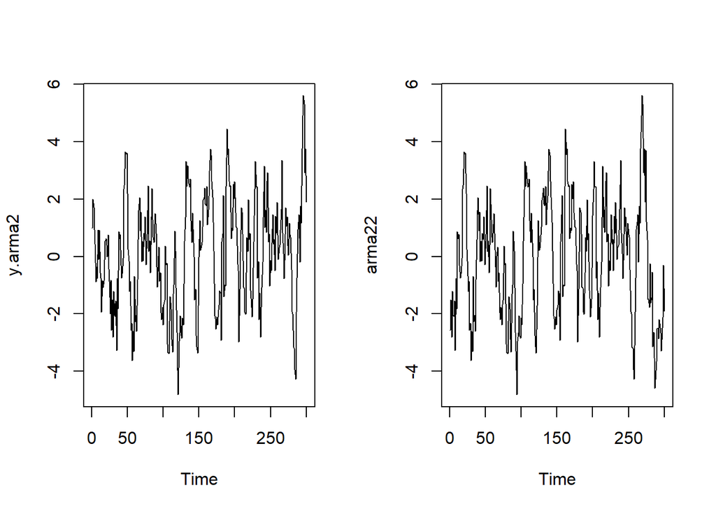

```r
par(mfrow = c(1, 2))
ts.plot(y.arma2)
ts.plot(arma22)
```

```r
par(mfrow = c(1, 1))
```

Berdasarkan plot time series, dapat dilihat bahwa proses ARMA(2,2) berfluktuasi di sekitar rata-rata konstan tanpa adanya tren jangka panjang, serta memiliki varians yang relatif stabil dari waktu ke waktu. Hal ini menunjukkan bahwa data hasil simulasi, baik dari bangkitan manual maupun dengan fungsi arima.sim(), bersifat stasioner.

###Plot ACF

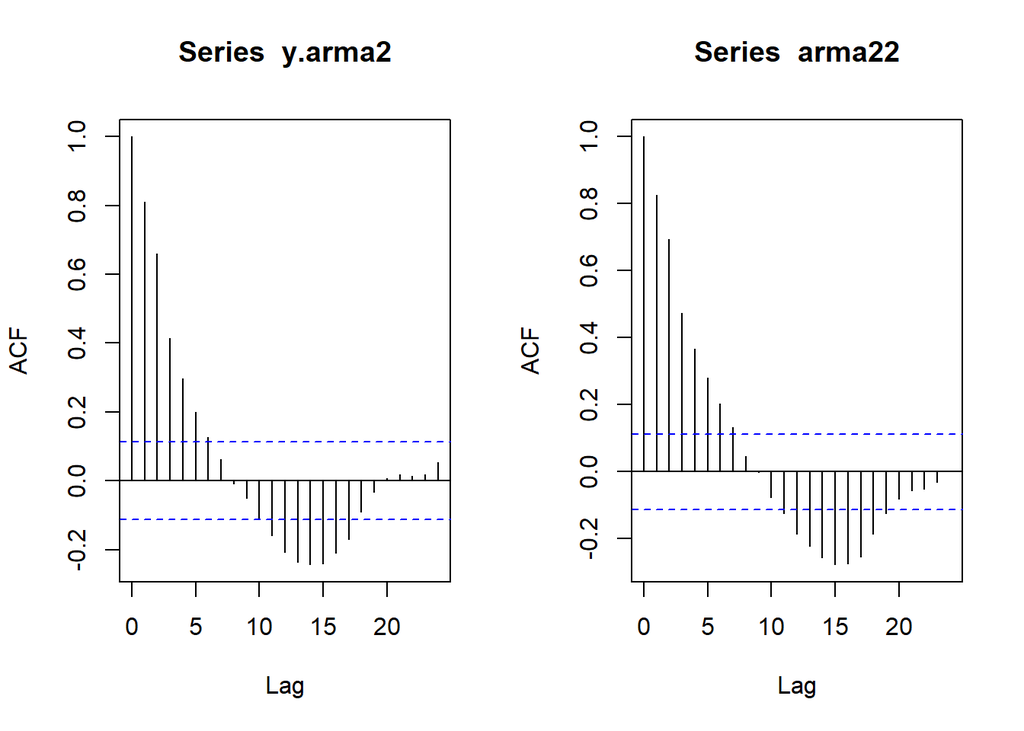

```r
par(mfrow = c(1, 2))
acf(y.arma2)
acf(arma22)
```

### Plot PACF

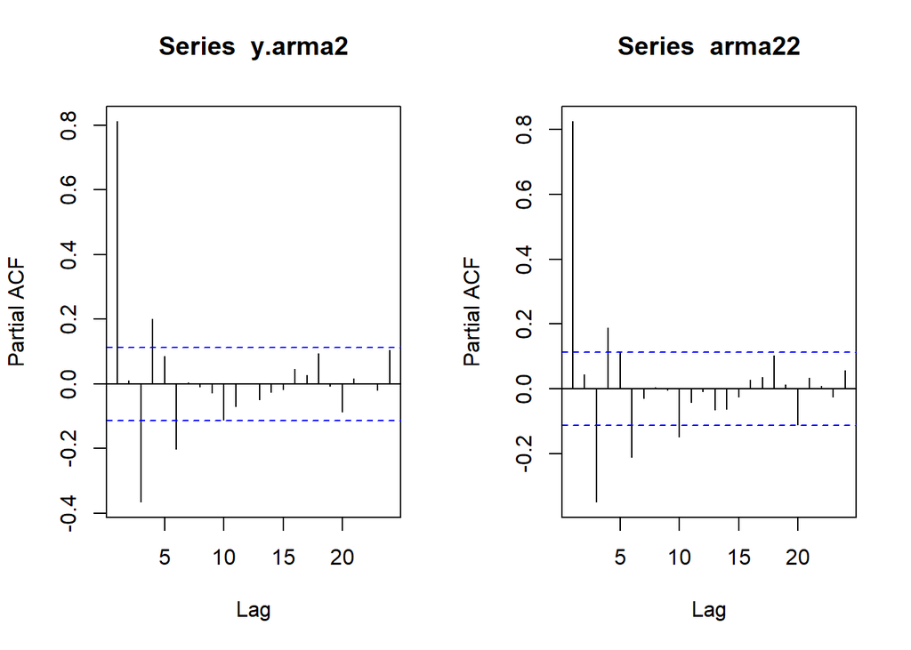

```r
par(mfrow = c(1, 2))
pacf(y.arma2)
pacf(arma22)
```

Plot PACF untuk y.arma2 dan arma22, terlihat bahwa hanya pada beberapa lag awal nilai PACF yang signifikan, kemudian menurun dan berada dalam batas interval kepercayaan. Hal ini sesuai dengan sifat model ARMA, di mana PACF tidak cut off secara jelas seperti pada murni AR(p), melainkan juga menunjukkan pola *tails off.*

### Plot EACF

```r
TSA::eacf(y.arma2)
```

```
## AR/MA
##   0 1 2 3 4 5 6 7 8 9 10 11 12 13
## 0 x x x x x x o o o o x  x  x  x
## 1 o x x o o o o o o o o  o  o  o
## 2 o x o x o o o o o o o  o  o  o
## 3 x x o o o o o o o o o  o  o  o
## 4 x x x o o o o o o o o  o  o  o
## 5 x x x o x x o o o o o  o  o  o
## 6 o o o x x o o o x o o  o  o  o
## 7 x o o x x x o o o o o  o  o  o
```

```r
TSA::eacf(arma22)
```

```
## AR/MA
##   0 1 2 3 4 5 6 7 8 9 10 11 12 13
## 0 x x x x x x x o o o x  x  x  x
## 1 o x x o o o o o o o o  o  o  o
## 2 o x x o o o o o o o o  o  o  o
## 3 x x o o o o o o o o o  o  o  o
## 4 x x o o o o o o o o o  o  o  o
## 5 x x x x x x o o o o o  o  o  o
## 6 x o o x o o o o x o o  o  o  o
## 7 x o o x x x o o o o o  o  o  o
```

### Korelasi antara $Y_t$ dengan $Y_t-1$

```r
#Yt
yt_arma <- arma22[-1]
yt_arma
```

```
##   [1] -1.504766185 -2.799923750 -1.205523662 -2.052963745 -2.091614868
##   [6] -1.552193010 -3.259884587 -0.767087538 -1.832826060  0.857264976
##  [11]  0.628961928  0.770716576 -0.299009449 -0.742175453 -0.594390076
##  [16] -0.059146016  2.339379877  2.479842507  3.642456278  3.573910489
##  [21]  3.599886828  2.187675710  0.247957718 -0.163902035 -1.206920232
##  [26] -0.853742487 -2.561367616 -2.315600987 -3.624867026 -2.604050045
##  [31] -3.301294568 -0.697745932 -2.267311020 -2.051686170 -2.609803672
##  [36] -0.802110234  0.576463967  1.610689196  2.040912739  0.896718426
##  [41]  1.553210220 -0.178538412  0.534028565 -0.153555320  0.798795967
##  [46]  0.605048685  1.377924469 -0.278954644  0.275229388  0.774268316
##  [51]  2.456817621  0.175690568  0.552773678 -0.556264171  0.397982751
##  [56]  2.356861267  1.290904907  0.684958254  0.484198305  1.119587547
##  [61]  1.496893983  0.814579947 -0.369665312 -1.056939974  0.007460283
##  [66]  0.316744606 -0.868260736 -0.558833466 -1.948364723 -2.189213474
##  [71] -1.767288364 -2.380046438 -1.674812394 -1.536716863  0.353075666
```

[output cut: 45 more lines]

```r
#Yt-1
yt_1_arma <- arma22[-300]
yt_1_arma
```

```
##   [1] -2.566071942 -1.504766185 -2.799923750 -1.205523662 -2.052963745
##   [6] -2.091614868 -1.552193010 -3.259884587 -0.767087538 -1.832826060
##  [11]  0.857264976  0.628961928  0.770716576 -0.299009449 -0.742175453
##  [16] -0.594390076 -0.059146016  2.339379877  2.479842507  3.642456278
##  [21]  3.573910489  3.599886828  2.187675710  0.247957718 -0.163902035
##  [26] -1.206920232 -0.853742487 -2.561367616 -2.315600987 -3.624867026
##  [31] -2.604050045 -3.301294568 -0.697745932 -2.267311020 -2.051686170
##  [36] -2.609803672 -0.802110234  0.576463967  1.610689196  2.040912739
##  [41]  0.896718426  1.553210220 -0.178538412  0.534028565 -0.153555320
##  [46]  0.798795967  0.605048685  1.377924469 -0.278954644  0.275229388
##  [51]  0.774268316  2.456817621  0.175690568  0.552773678 -0.556264171
##  [56]  0.397982751  2.356861267  1.290904907  0.684958254  0.484198305
##  [61]  1.119587547  1.496893983  0.814579947 -0.369665312 -1.056939974
##  [66]  0.007460283  0.316744606 -0.868260736 -0.558833466 -1.948364723
##  [71] -2.189213474 -1.767288364 -2.380046438 -1.674812394 -1.536716863
```

[output cut: 45 more lines]

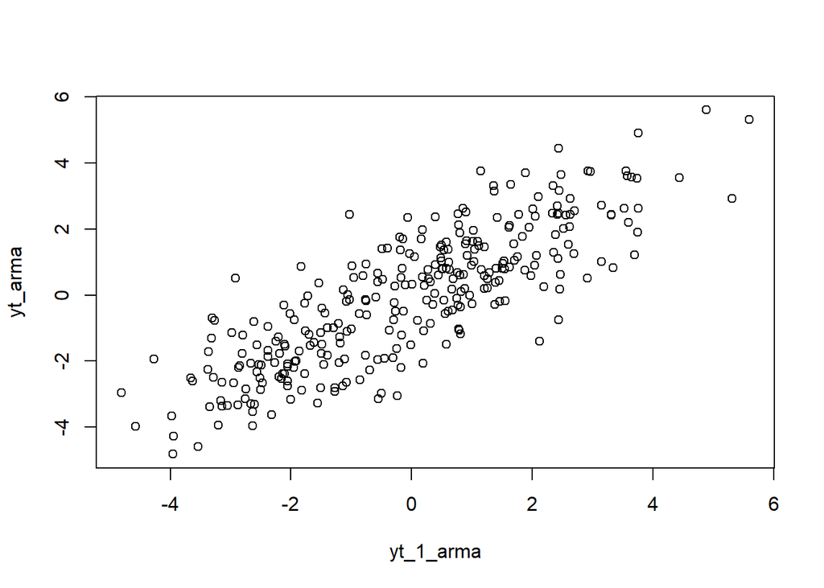

```r
plot(y=yt_arma,x=yt_1_arma)
```

```r
cor(yt_arma,yt_1_arma)
```

```
## [1] 0.8283344
```

Hubungan ini sangat kuat dan positif, yang berarti nilai $Y_t$ cenderung bergerak searah dengan nilai lag-1 $Y_t-1$ Ketika $Y_t-1$ tinggi, maka $Y_t$ juga cenderung tinggi, dan sebaliknya. Pola ini konsisten dengan sifat model ARMA, terutama komponen AR yang memasukkan ketergantungan kuat pada lag sebelumnya.

### Korelasi antara $Y_t$ dengan $Y_t-2$

```r
#Yt
yt_arma2 <- arma22[-c(1,2)]
yt_arma2
```

```
##   [1] -2.799923750 -1.205523662 -2.052963745 -2.091614868 -1.552193010
##   [6] -3.259884587 -0.767087538 -1.832826060  0.857264976  0.628961928
##  [11]  0.770716576 -0.299009449 -0.742175453 -0.594390076 -0.059146016
##  [16]  2.339379877  2.479842507  3.642456278  3.573910489  3.599886828
##  [21]  2.187675710  0.247957718 -0.163902035 -1.206920232 -0.853742487
##  [26] -2.561367616 -2.315600987 -3.624867026 -2.604050045 -3.301294568
##  [31] -0.697745932 -2.267311020 -2.051686170 -2.609803672 -0.802110234
##  [36]  0.576463967  1.610689196  2.040912739  0.896718426  1.553210220
##  [41] -0.178538412  0.534028565 -0.153555320  0.798795967  0.605048685
##  [46]  1.377924469 -0.278954644  0.275229388  0.774268316  2.456817621
##  [51]  0.175690568  0.552773678 -0.556264171  0.397982751  2.356861267
##  [56]  1.290904907  0.684958254  0.484198305  1.119587547  1.496893983
##  [61]  0.814579947 -0.369665312 -1.056939974  0.007460283  0.316744606
##  [66] -0.868260736 -0.558833466 -1.948364723 -2.189213474 -1.767288364
##  [71] -2.380046438 -1.674812394 -1.536716863  0.353075666 -0.288109796
```

[output cut: 45 more lines]

```r
#Yt-2
yt_2_arma <- arma22[-c(299,300)]
yt_2_arma
```

```
##   [1] -2.566071942 -1.504766185 -2.799923750 -1.205523662 -2.052963745
##   [6] -2.091614868 -1.552193010 -3.259884587 -0.767087538 -1.832826060
##  [11]  0.857264976  0.628961928  0.770716576 -0.299009449 -0.742175453
##  [16] -0.594390076 -0.059146016  2.339379877  2.479842507  3.642456278
##  [21]  3.573910489  3.599886828  2.187675710  0.247957718 -0.163902035
##  [26] -1.206920232 -0.853742487 -2.561367616 -2.315600987 -3.624867026
##  [31] -2.604050045 -3.301294568 -0.697745932 -2.267311020 -2.051686170
##  [36] -2.609803672 -0.802110234  0.576463967  1.610689196  2.040912739
##  [41]  0.896718426  1.553210220 -0.178538412  0.534028565 -0.153555320
##  [46]  0.798795967  0.605048685  1.377924469 -0.278954644  0.275229388
##  [51]  0.774268316  2.456817621  0.175690568  0.552773678 -0.556264171
##  [56]  0.397982751  2.356861267  1.290904907  0.684958254  0.484198305
##  [61]  1.119587547  1.496893983  0.814579947 -0.369665312 -1.056939974
##  [66]  0.007460283  0.316744606 -0.868260736 -0.558833466 -1.948364723
##  [71] -2.189213474 -1.767288364 -2.380046438 -1.674812394 -1.536716863
```

[output cut: 45 more lines]

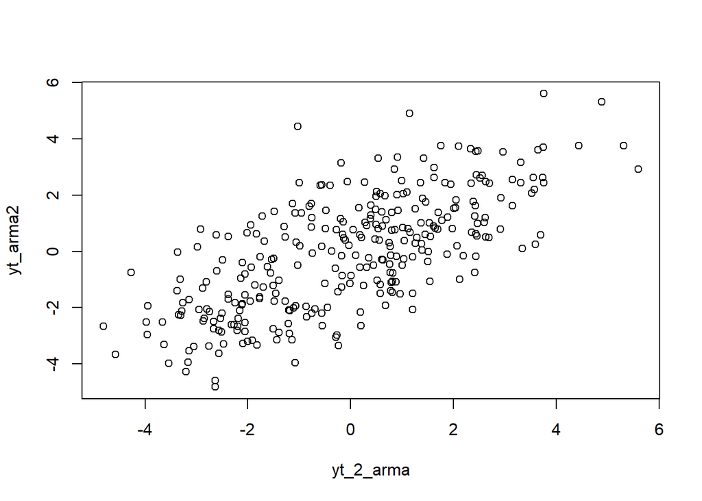

```r
plot(y=yt_arma2,x=yt_2_arma)
```

```r
cor(yt_arma2,yt_2_arma)
```

```
## [1] 0.6981956
```

Hubungan ini masih cukup kuat dan positif, meskipun tidak sekuat korelasi lag-1. Artinya, nilai $Y_t$ masih dipengaruhi oleh nilai dua periode sebelumnya $Y_t-2$ tetapi kekuatannya menurun dibanding pengaruh lag pertama. Pola ini sejalan dengan karakteristik model AR(2) atau ARMA(2,2), di mana ketergantungan tidak hanya muncul pada lag pertama tetapi juga lag kedua.

### Korelasi antara $Y_t$ dengan $Y_t-3$

```r
#Yt
yt_arma3 <- arma22[-c(1,2,3)]
yt_arma3
```

```
##   [1] -1.205523662 -2.052963745 -2.091614868 -1.552193010 -3.259884587
##   [6] -0.767087538 -1.832826060  0.857264976  0.628961928  0.770716576
##  [11] -0.299009449 -0.742175453 -0.594390076 -0.059146016  2.339379877
##  [16]  2.479842507  3.642456278  3.573910489  3.599886828  2.187675710
##  [21]  0.247957718 -0.163902035 -1.206920232 -0.853742487 -2.561367616
##  [26] -2.315600987 -3.624867026 -2.604050045 -3.301294568 -0.697745932
##  [31] -2.267311020 -2.051686170 -2.609803672 -0.802110234  0.576463967
##  [36]  1.610689196  2.040912739  0.896718426  1.553210220 -0.178538412
##  [41]  0.534028565 -0.153555320  0.798795967  0.605048685  1.377924469
##  [46] -0.278954644  0.275229388  0.774268316  2.456817621  0.175690568
##  [51]  0.552773678 -0.556264171  0.397982751  2.356861267  1.290904907
##  [56]  0.684958254  0.484198305  1.119587547  1.496893983  0.814579947
##  [61] -0.369665312 -1.056939974  0.007460283  0.316744606 -0.868260736
##  [66] -0.558833466 -1.948364723 -2.189213474 -1.767288364 -2.380046438
##  [71] -1.674812394 -1.536716863  0.353075666 -0.288109796 -0.239699744
```

[output cut: 45 more lines]

```r
#Yt-2
yt_3_arma <- arma22[-c(298,299,300)]
yt_3_arma
```

```
##   [1] -2.566071942 -1.504766185 -2.799923750 -1.205523662 -2.052963745
##   [6] -2.091614868 -1.552193010 -3.259884587 -0.767087538 -1.832826060
##  [11]  0.857264976  0.628961928  0.770716576 -0.299009449 -0.742175453
##  [16] -0.594390076 -0.059146016  2.339379877  2.479842507  3.642456278
##  [21]  3.573910489  3.599886828  2.187675710  0.247957718 -0.163902035
##  [26] -1.206920232 -0.853742487 -2.561367616 -2.315600987 -3.624867026
##  [31] -2.604050045 -3.301294568 -0.697745932 -2.267311020 -2.051686170
##  [36] -2.609803672 -0.802110234  0.576463967  1.610689196  2.040912739
##  [41]  0.896718426  1.553210220 -0.178538412  0.534028565 -0.153555320
##  [46]  0.798795967  0.605048685  1.377924469 -0.278954644  0.275229388
##  [51]  0.774268316  2.456817621  0.175690568  0.552773678 -0.556264171
##  [56]  0.397982751  2.356861267  1.290904907  0.684958254  0.484198305
##  [61]  1.119587547  1.496893983  0.814579947 -0.369665312 -1.056939974
##  [66]  0.007460283  0.316744606 -0.868260736 -0.558833466 -1.948364723
##  [71] -2.189213474 -1.767288364 -2.380046438 -1.674812394 -1.536716863
```

[output cut: 45 more lines]

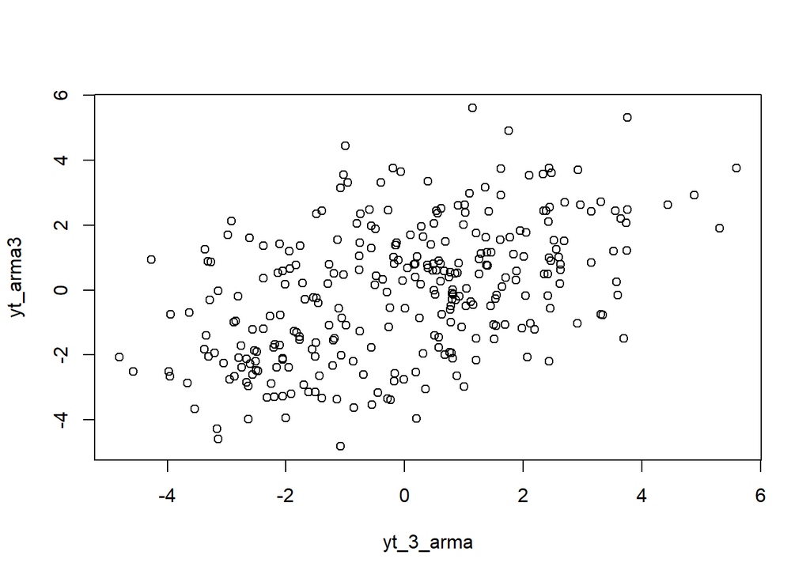

```r
plot(y=yt_arma3,x=yt_3_arma)
```

```r
cor(yt_arma3,yt_3_arma)
```

```
## [1] 0.4775703
```

Hubungan ini masih positif, tetapi semakin melemah dibandingkan lag-1 dan lag-2. Artinya, nilai $Y_t$ memang masih dipengaruhi oleh nilai tiga periode sebelumnya $Y_t-3$ namun pengaruhnya mulai berkurang. Pola penurunan korelasi dari lag-1, lag-2, hingga lag-3 ini konsisten dengan sifat proses AR(2) atau ARMA(2,2), di mana korelasi secara teoritis akan semakin mengecil seiring bertambahnya lag, hingga akhirnya mendekati nol.

### Perhitungan Korelasi Teoritis

Model ARMA(2,2):

$$Y_t = 0.5 Y_{t-1} + 0.2 Y_{t-2} + e_t + 0.4 e_{t-1} + 0.6 e_{t-2},
\quad e_t \sim WN(0,\sigma^2)$$

Representasi MA($\infty$):

$$Y_t = \sum_{j=0}^\infty \psi_j e_{t-j}$$

dengan rekursi:

$$\psi_0 = 1$$

$$\psi_1 = 0.5 \cdot \psi_0 + 0.4 = 0.5(1) + 0.4 = 0.9$$

$$\psi_2 = 0.5 \cdot \psi_1 + 0.2 \cdot \psi_0 + 0.6 = 0.5(0.9) + 0.2(1) +
0.6 = 1.25$$

$$\psi_j = 0.5 \psi_{j-1} + 0.2 \psi_{j-2}, \quad j \geq 3$$

Autokovarians:

$$\gamma_k = \sigma^2 \sum_{j=0}^\infty \psi_j \psi_{j+k}$$

Autokorelasi:

$$\rho_k = \frac{\gamma_k}{\gamma_0}$$

Sehingga untuk $k = 1,2,3$:

$$\rho_1 = \frac{\gamma_1}{\gamma_0}, \quad
\rho_2 = \frac{\gamma_2}{\gamma_0}, \quad
\rho_3 = \frac{\gamma_3}{\gamma_0}$$

```r
# Parameter
phi1 <- 0.5
phi2 <- 0.2
theta1 <- 0.4
theta2 <- 0.6
sigma2 <- 1   #tidak tergantung sigma2

# Banyak psi yang dihitung (M besar untuk aproksimasi)
M <- 200

# Hitung psi_j
psi <- numeric(M+1)
psi[1] <- 1            # psi_0 = 1  -> index 1 di R
if (M >= 1) psi[2] <- phi1 * psi[1] + theta1  # psi_1
if (M >= 2) psi[3] <- phi1 * psi[2] + phi2 * psi[1] + theta2  # psi_2
if (M >= 3) {
  for (k in 4:(M+1)) { # k di R index = j+1
    psi[k] <- phi1 * psi[k-1] + phi2 * psi[k-2]
  }
}

# Fungsi untuk gamma_k aproksimasi
gamma_k <- function(k, psi_vec) {
  # gamma_k = sum_{j=0..M-k} psi_j * psi_{j+k}
  # indeks R: psi[j+1] * psi[j+k+1]
  M <- length(psi_vec) - 1
  s <- 0
  for (j in 0:(M - k)) {
    s <- s + psi_vec[j+1] * psi_vec[j+k+1]
  }
  return(s * sigma2)
}

# Hitung gamma_0, gamma_1, gamma_2, gamma_3
gamma0 <- gamma_k(0, psi)
gamma1 <- gamma_k(1, psi)
gamma2 <- gamma_k(2, psi)
gamma3 <- gamma_k(3, psi)

# Autokorelasi
rho1 <- gamma1 / gamma0
rho2 <- gamma2 / gamma0
rho3 <- gamma3 / gamma0

rho1
```

```
## [1] 0.8591993
```

```r
rho2
```

```
## [1] 0.7491908
```

```r
rho3
```

```
## [1] 0.5464353
```